# Predicting Tennis Match Winners and Losers

#### AIT580

#### Final Class Project

- Hunter Walden, Kevin Mitchell, Jason Myslewski
- 13 July 2022

## Introduction

Is it possible to determine if a tennis player is a winner or a loser based on their match statistics? We set out to determine if this was possible using data from major tennis tournament matches. There are a number of statistics collected on each tennis player as a result of their match. Important statistics include set scores, total points won, winning shots, unforced errors, net points won, break points won, first and second serve percentages and net points won, among many others. In order to find a solution to our question, we determined what statistics were most important and used those for predictive analysis.

## Purpose

The purpose of this project is to determine which statistical attributes have the most effect on the outcome (win/loss) of a tennis match, and to predict if a player was a winner or a loser.

## Methods

- **Tools used include**: python, Jupyter Lab, SciKit Learn, pandas, numpy, seaborn, matplotlib.
- **Data cleaning methods include**: concatenating, renaming columns, dropping NaN, removing outliers, visualizing data.
- **Predictive analysis methods**: logistic regression, naive Bayes, KNN

### Column Name Meanings:

**Attribute Information:**

1. Player 1 Name of Player 1
2. Player 2 Name of Player 2
3. Result Result of the match (0/1) - Referenced on Player 1 is Result = 1 if Player 1 wins (FNL.1>FNL.2)
4. FSP.1 First Serve Percentage for player 1 (Real Number)
5. FSW.1 First Serve Won by player 1 (Real Number)
6. SSP.1 Second Serve Percentage for player 1 (Real Number)
7. SSW.1 Second Serve Won by player 1 (Real Number)
8. ACE.1 Aces won by player 1 (Numeric-Integer)
9. DBF.1 Double Faults committed by player 1 (Numeric-Integer)
10. WNR.1 Winners earned by player 1 (Numeric)
11. UFE.1 Unforced Errors committed by player 1 (Numeric)
12. BPC.1 Break Points Created by player 1 (Numeric)
13. BPW.1 Break Points Won by player 1 (Numeric)
14. NPA.1 Net Points Attempted by player 1 (Numeric)
15. NPW.1 Net Points Won by player 1 (Numeric)
16. TPW.1 Total Points Won by player 1 (Numeric)
17. ST1.1 Set 1 result for Player 1 (Numeric-Integer)
18. ST2.1 Set 2 Result for Player 1 (Numeric-Integer)
19. ST3.1 Set 3 Result for Player 1 (Numeric-Integer)
20. ST4.1 Set 4 Result for Player 1 (Numeric-Integer)
21. ST5.1 Set 5 Result for Player 1 (Numeric-Integer)
22. FNL.1 Final Number of Games Won by Player 1 (Numeric-Integer)
23. FSP.2 First Serve Percentage for player 2 (Real Number)
24. FSW.2 First Serve Won by player 2 (Real Number)
25. SSP.2 Second Serve Percentage for player 2 (Real Number)
26. SSW.2 Second Serve Won by player 2 (Real Number)
27. ACE.2 Aces won by player 2 (Numeric-Integer)
28. DBF.2 Double Faults committed by player 2 (Numeric-Integer)
29. WNR.2 Winners earned by player 2 (Numeric)
30. UFE.2 Unforced Errors committed by player 2 (Numeric)
31. BPC.2 Break Points Created by player 2 (Numeric)
32. BPW.2 Break Points Won by player 2 (Numeric)
33. NPA.2 Net Points Attempted by player 2 (Numeric)
34. NPW.2 Net Points Won by player 2 (Numeric)
35. TPW.2 Total Points Won by player 2 (Numeric)
36. ST1.2 Set 1 result for Player 2 (Numeric-Integer)
37. ST2.2 Set 2 Result for Player 2 (Numeric-Integer)
38. ST3.2 Set 3 Result for Player 2 (Numeric-Integer)
39. ST4.2 Set 4 Result for Player 2 (Numeric-Integer)
40. ST5.2 Set 5 Result for Player 2 (Numeric-Integer)
41. FNL.2 Final Number of Games Won by Player 2 (Numeric-Integer)
42. Round Round of the tournament at which game is played (Numeric-Integer)

## Part 1: Data Cleaning

#### Data Cleaning Checklist

1. Import data sets
2. Rename columns
3. Concatenate sets
4. Check for consistency in data types.
5. Check for duplicate rows
6. Validate and create the final data set.

```python
# import libraries
import re
import matplotlib.pyplot as plt
import numpy as np
import pandas as pd
import seaborn as sns
from sklearn import preprocessing
from sklearn.datasets import make_classification, make_blobs
from sklearn.linear_model import LogisticRegression
from sklearn.model_selection import train_test_split
from sklearn.naive_bayes import GaussianNB
from sklearn.pipeline import make_pipeline
from sklearn.preprocessing import StandardScaler
from sklearn import metrics
from sklearn.metrics import confusion_matrix, ConfusionMatrixDisplay, accuracy_score
from sklearn.neighbors import KNeighborsClassifier
```

```python
pd.set_option('display.max_columns', None)
pd.set_option('display.max_rows', None)
```

```python
# import csv files
aus_men = pd.read_csv("AusOpen-men-2013.csv")
aus_women = pd.read_csv("AusOpen-women-2013.csv")
french_men = pd.read_csv("FrenchOpen-men-2013.csv")
french_women = pd.read_csv("FrenchOpen-women-2013.csv")
us_men = pd.read_csv("USOpen-men-2013.csv")
us_women = pd.read_csv("USOpen-women-2013.csv")
wimb_men = pd.read_csv("Wimbledon-men-2013.csv")
wimb_women = pd.read_csv("Wimbledon-women-2013.csv")
```

```python
# create a list of all 8 data frames
dfs = [aus_men, aus_women, french_men, french_women, us_men, us_women,
       wimb_men, wimb_women]

# create a list of the column names as they need to appear in each df
col_names = ['Player1', 'Player2', 'Round', 'Result', 'FNL.1', 'FNL.2',
             'FSP.1','FSW.1', 'SSP.1', 'SSW.1', 'ACE.1', 'DBF.1', 'WNR.1',
             'UFE.1', 'BPC.1', 'BPW.1', 'NPA.1', 'NPW.1', 'TPW.1', 'ST1.1',
             'ST2.1', 'ST3.1', 'ST4.1', 'ST5.1', 'FSP.2', 'FSW.2', 'SSP.2',
             'SSW.2', 'ACE.2', 'DBF.2', 'WNR.2', 'UFE.2', 'BPC.2', 'BPW.2',
             'NPA.2', 'NPW.2', 'TPW.2', 'ST1.2', 'ST2.2', 'ST3.2', 'ST4.2',
             'ST5.2']
```

```python
# function to check column names
def column_checker(dfs, colNames):
    '''This function will check all the column names in each data frame
    to match the column names that are listed in the standardized list
    of column names.

    The function will return the column name that is incorrect, and the
    number of names that are incorrect for each data frame.
    '''
    num = 0
    for data in dfs:
        rename = []
        for i in range(len(col_names)):
            li = list(data.columns)
            if li[i] != col_names[i]:
                print(f'{li[i]} needs to be fixed')
                rename.append(li[i])
        print(f'{len(rename)} columns need to be renamed in dfs[{num}]')
        print('-----')
        num += 1
        rename.clear()
```

```python
column_checker(dfs, col_names)
```

```
FNL1 needs to be fixed
FNL2 needs to be fixed
2 columns need to be renamed in dfs[0]
-----
FNL1 needs to be fixed
FNL2 needs to be fixed
2 columns need to be renamed in dfs[1]
-----
0 columns need to be renamed in dfs[2]
-----
0 columns need to be renamed in dfs[3]
-----
FNL1 needs to be fixed
FNL2 needs to be fixed
2 columns need to be renamed in dfs[4]
-----
Player 1 needs to be fixed
Player 2 needs to be fixed
ROUND needs to be fixed
ST2.1.1 needs to be fixed
4 columns need to be renamed in dfs[5]
-----
0 columns need to be renamed in dfs[6]
-----
ST1.1.1 needs to be fixed
1 columns need to be renamed in dfs[7]
-----
```

During the initial inspection of each of the 8 data frames above, we noticed there are many columns that have inconsistent naming convention. Below we identified the specific columns in each data frame that required renaming, then printed the column names of each data frame to validae consistency.

```python
# rename columns for consistency
aus_men = aus_men.rename(columns={'FNL1': 'FNL.1', 'FNL2': 'FNL.2'})
aus_women = aus_women.rename(columns={'FNL1': 'FNL.1', 'FNL2': 'FNL.2'})
us_men = us_men.rename(columns={'FNL1': 'FNL.1', 'FNL2': 'FNL.2'})
us_women = us_women.rename(columns={'ST2.1.1': 'ST1.2', 'Player 1': 'Player1',
                                    'Player 2': 'Player2', 'ROUND':'Round'})
wimb_women = wimb_women.rename(columns={'ST1.1.1': 'ST1.2'})
```

Below we validate that all the column names are identical and ready for concatenating.

```python
# create a new list to check col names using our column_checker function
dfs1 = [aus_men, aus_women, french_men, french_women,
        us_men, us_women, wimb_men, wimb_women]
column_checker(dfs1, col_names)
```

```
0 columns need to be renamed in dfs[0]
-----
0 columns need to be renamed in dfs[1]
-----
0 columns need to be renamed in dfs[2]
-----
0 columns need to be renamed in dfs[3]
-----
0 columns need to be renamed in dfs[4]
-----
0 columns need to be renamed in dfs[5]
-----
0 columns need to be renamed in dfs[6]
-----
0 columns need to be renamed in dfs[7]
-----
```

All column names are fixed and the data frames are ready to be concatenated. We will concatenate all 8 data frames regardless of tournament name and agnostic to gender.

```python
# look at the shape of each individual data frame.
for d in dfs:
    print(d.shape)
```

```
(126, 42)
(127, 42)
(125, 42)
(127, 42)
(126, 42)
(76, 42)
(114, 42)
(122, 42)
```

```python
# concatentate all 8 data frames into one.
df = pd.concat(dfs1)
```

Now that all 8 data frames are concatenated into one data frame, we need to do some more manipulation. Each row of the data frame contains stats for each match and includes information on both player 1 and player 2. We need to have a data frame where every row is one discrete player and contains an appropriate win/loss label i.e. (1, 0). Below we will divide the columns and create two data frames based on player 1 and player 2. Then we will reindex the columns and rename the columns so that both data frames are identical. We will also add a win/loss label to player two data frame. We will concatenate both player1 and player 2 data frames into one final data frame that will be ready for exploration.

```python
# data frame manipulate to generate a dataframe that has one discrete
# player per row.
player_1 = df[['Result', 'FNL.1', 'FSP.1','FSW.1', 'SSP.1',
              'SSW.1', 'ACE.1', 'DBF.1', 'WNR.1', 'UFE.1', 'BPC.1',
              'BPW.1', 'NPA.1', 'NPW.1', 'TPW.1', 'ST1.1', 'ST2.1',
              'ST3.1', 'ST4.1', 'ST5.1']]
player_2 = df[['FNL.2', 'FSP.2', 'FSW.2', 'SSP.2', 'SSW.2', 'ACE.2',
               'DBF.2', 'WNR.2', 'UFE.2', 'BPC.2', 'BPW.2', 'NPA.2',
               'NPW.2', 'TPW.2', 'ST1.2', 'ST2.2', 'ST3.2', 'ST4.2',
               'ST5.2']]

# assign win/loss (1, 0) values and assign to player 2 data frame
win_loss_p1 = list(player_1['Result'])
win_loss_p2 = []
for result in win_loss_p1:
    if result == 0:
        win_loss_p2.append(1)
    elif result == 1:
        win_loss_p2.append(0)

# validate the results column gererated correctly
# each listed result should be opposite
print(f'player_1 results {win_loss_p1[:10]}')
print(f'player_2 results {win_loss_p2[:10]}')

player_2.loc[:, 'Result'] = win_loss_p2
col_order = ['Result', 'FNL.2', 'FSP.2', 'FSW.2', 'SSP.2', 'SSW.2',
             'ACE.2', 'DBF.2', 'WNR.2', 'UFE.2', 'BPC.2', 'BPW.2',
             'NPA.2', 'NPW.2', 'TPW.2', 'ST1.2', 'ST2.2', 'ST3.2',
             'ST4.2', 'ST5.2']
player_2 = player_2.reindex(columns=col_order)
```

```
player_1 results [0, 1, 0, 1, 0, 0, 0, 1, 0, 1]
player_2 results [1, 0, 1, 0, 1, 1, 1, 0, 1, 0]
```

```python
# rename columns in both data frames
def rename_cols(df):
    '''This function takes the column names of a data frame and returns
    the same data frame with updated column names.
    '''
    old_cols = list(df.columns)
    new_names = []
    for name in old_cols:
        new = re.sub('\.\d', '', name)
        new_names.append(new)
    d = {key:value for key, value in zip(old_cols, new_names)}
    df2 = df.rename(columns=d)
    return df2
```

```python
# standardize col names between player_1 and player_2 data frames:
player_1 = rename_cols(player_1)
player_2 = rename_cols(player_2)
```

```python
# concatenate player_1 and player_2 data frames:
concats = [player_1, player_2]
df2 = pd.concat(concats)
df2.info()      # should be the 2x rows and .5x cols as df.info()
```

```
<class 'pandas.core.frame.DataFrame'>
Int64Index: 1886 entries, 0 to 121
Data columns (total 20 columns):
 #   Column  Non-Null Count  Dtype
---  ------  --------------  -----
 0   Result  1886 non-null   int64
 1   FNL     1884 non-null   float64
 2   FSP     1886 non-null   int64
 3   FSW     1886 non-null   int64
 4   SSP     1886 non-null   int64
 5   SSW     1886 non-null   int64
 6   ACE     1842 non-null   float64
 7   DBF     1870 non-null   float64
 8   WNR     1634 non-null   float64
 9   UFE     1634 non-null   float64
 10  BPC     1884 non-null   float64
 11  BPW     1884 non-null   float64
 12  NPA     1718 non-null   float64
 13  NPW     1720 non-null   float64
 14  TPW     1262 non-null   float64
 15  ST1     1884 non-null   float64
 16  ST2     1878 non-null   float64
 17  ST3     1244 non-null   float64
 18  ST4     442 non-null    float64
 19  ST5     172 non-null    float64
dtypes: float64(15), int64(5)
memory usage: 309.4 KB
```

```python
# check for duplicate rows:
df2.duplicated().value_counts()
```

```
False    1886
dtype: int64
```

```python
# fill NaN values
med = df2.median()
avg = df2.mean()
df2 = df2.drop(['TPW', 'ST4', 'ST5', 'ST3'], axis=1)
df2 = df2.dropna()
```

We ended up dropping all NaN values.

```python
df2 = df2.reset_index().drop('index', axis=1)
# save the processed data set that we will use for exploratory analysis
df2.to_csv('MasterDFv2.csv')
df2.info()
```

```
<class 'pandas.core.frame.DataFrame'>
RangeIndex: 1478 entries, 0 to 1477
Data columns (total 16 columns):
 #   Column  Non-Null Count  Dtype
---  ------  --------------  -----
 0   Result  1478 non-null   int64
 1   FNL     1478 non-null   float64
 2   FSP     1478 non-null   int64
 3   FSW     1478 non-null   int64
 4   SSP     1478 non-null   int64
 5   SSW     1478 non-null   int64
 6   ACE     1478 non-null   float64
 7   DBF     1478 non-null   float64
 8   WNR     1478 non-null   float64
 9   UFE     1478 non-null   float64
 10  BPC     1478 non-null   float64
 11  BPW     1478 non-null   float64
 12  NPA     1478 non-null   float64
 13  NPW     1478 non-null   float64
 14  ST1     1478 non-null   float64
 15  ST2     1478 non-null   float64
dtypes: float64(11), int64(5)
memory usage: 184.9 KB
```

## Part 2: Exploratory Analysis

#### Check for outliers

```python
# look at the data frame as a whole (excluding first 4 columns, irrlelvant)
df2.describe().round(1)
```

|  | Result | FNL | FSP | FSW | SSP | SSW | ACE | DBF | WNR | UFE | BPC | BPW | NPA | NPW | ST1 | ST2 |
| --- | --- | --- | --- | --- | --- | --- | --- | --- | --- | --- | --- | --- | --- | --- | --- | --- |
| count | 1478.0 | 1478.0 | 1478.0 | 1478.0 | 1478.0 | 1478.0 | 1478.0 | 1478.0 | 1478.0 | 1478.0 | 1478.0 | 1478.0 | 1478.0 | 1478.0 | 1478.0 | 1478.0 |
| mean | 0.5 | 1.4 | 62.6 | 38.0 | 37.4 | 16.0 | 5.6 | 3.5 | 29.4 | 29.1 | 5.5 | 6.5 | 15.7 | 16.2 | 4.8 | 4.8 |
| std | 0.5 | 1.1 | 7.9 | 17.6 | 7.9 | 8.1 | 5.9 | 2.6 | 15.5 | 14.3 | 4.1 | 4.8 | 12.5 | 11.2 | 1.9 | 1.9 |
| min | 0.0 | 0.0 | 39.0 | 6.0 | 7.0 | 1.0 | 0.0 | 0.0 | 2.0 | 2.0 | 0.0 | 0.0 | 0.0 | 0.0 | 0.0 | 0.0 |
| 25% | 0.0 | 0.0 | 57.0 | 25.0 | 32.0 | 10.0 | 1.0 | 2.0 | 18.0 | 18.0 | 2.0 | 3.0 | 7.0 | 8.0 | 3.0 | 3.0 |
| 50% | 0.5 | 2.0 | 63.0 | 35.0 | 37.0 | 15.0 | 4.0 | 3.0 | 27.0 | 27.0 | 5.0 | 5.0 | 13.0 | 14.0 | 6.0 | 6.0 |
| 75% | 1.0 | 2.0 | 68.0 | 47.0 | 43.0 | 21.0 | 8.0 | 5.0 | 38.0 | 37.0 | 7.0 | 10.0 | 20.0 | 22.0 | 6.0 | 6.0 |
| max | 1.0 | 3.0 | 93.0 | 132.0 | 61.0 | 57.0 | 41.0 | 18.0 | 111.0 | 96.0 | 25.0 | 26.0 | 96.0 | 80.0 | 7.0 | 7.0 |

```python
# determine variance for entire data set
var_full = np.var(df2).round(1)
print(var_full)
```

```
Result      0.2
FNL         1.3
FSP        62.8
FSW       310.1
SSP        62.9
SSW        65.2
ACE        34.5
DBF         6.6
WNR       239.7
UFE       204.8
BPC        17.2
BPW        23.0
NPA       155.4
NPW       124.5
ST1         3.7
ST2         3.8
dtype: float64
```

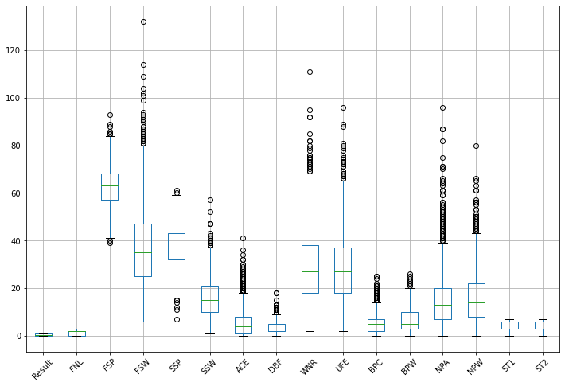

```python
# generate boxplots to look for outliers
df2.boxplot(column=list(df2.columns), figsize=(12, 8), rot=45)
```

```python
# for each column, determine the IQR, and the upper/lower bound for outliers
IQR = df2.quantile(0.75) - df2.quantile(0.25)
upper_fence = df2.quantile(0.75) + 1.5*(IQR)
lower_fence = df2.quantile(0.25) - 1.5*(IQR)

# apply the mask function to replace the outliers with the mean of each col
df2 = df2.mask((df2 >= upper_fence), other=avg, axis=1)
df2 = df2.mask((df2 <= lower_fence), other=avg, axis=1)
```

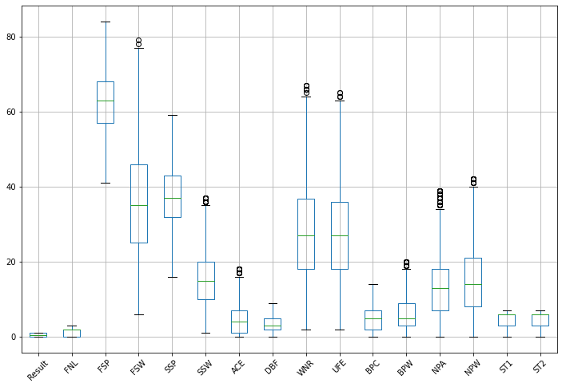

```python
# validate the replacement of the outliers with the mean
df2.boxplot(column=list(df2.columns), figsize=(12, 8), rot=45)
```

#### Correlations

```python
df2.corr().round(2)
```

|  | Result | FNL | FSP | FSW | SSP | SSW | ACE | DBF | WNR | UFE | BPC | BPW | NPA | NPW | ST1 | ST2 |
| --- | --- | --- | --- | --- | --- | --- | --- | --- | --- | --- | --- | --- | --- | --- | --- | --- |
| Result | 1.00 | 0.86 | 0.11 | 0.16 | -0.11 | 0.11 | 0.20 | -0.12 | 0.23 | -0.21 | 0.46 | 0.40 | 0.02 | -0.00 | 0.54 | 0.52 |
| FNL | 0.86 | 1.00 | 0.12 | 0.46 | -0.12 | 0.39 | 0.39 | -0.03 | 0.50 | -0.02 | 0.49 | 0.50 | 0.20 | 0.23 | 0.60 | 0.59 |
| FSP | 0.11 | 0.12 | 1.00 | 0.23 | -1.00 | -0.30 | -0.04 | -0.32 | 0.02 | -0.15 | 0.05 | 0.02 | 0.01 | -0.00 | 0.12 | 0.08 |
| FSW | 0.16 | 0.46 | 0.23 | 1.00 | -0.23 | 0.66 | 0.57 | 0.15 | 0.73 | 0.39 | 0.14 | 0.23 | 0.49 | 0.58 | 0.32 | 0.32 |
| SSP | -0.11 | -0.12 | -1.00 | -0.23 | 1.00 | 0.30 | 0.04 | 0.32 | -0.02 | 0.14 | -0.05 | -0.03 | -0.01 | -0.00 | -0.12 | -0.09 |
| SSW | 0.11 | 0.39 | -0.30 | 0.66 | 0.30 | 1.00 | 0.50 | 0.22 | 0.66 | 0.40 | 0.12 | 0.21 | 0.43 | 0.53 | 0.27 | 0.30 |
| ACE | 0.20 | 0.39 | -0.04 | 0.57 | 0.04 | 0.50 | 1.00 | 0.09 | 0.63 | 0.17 | 0.09 | 0.04 | 0.32 | 0.33 | 0.27 | 0.24 |
| DBF | -0.12 | -0.03 | -0.32 | 0.15 | 0.32 | 0.22 | 0.09 | 1.00 | 0.15 | 0.39 | 0.02 | 0.04 | 0.07 | 0.12 | -0.05 | -0.05 |
| WNR | 0.23 | 0.50 | 0.02 | 0.73 | -0.02 | 0.66 | 0.63 | 0.15 | 1.00 | 0.40 | 0.23 | 0.28 | 0.52 | 0.61 | 0.35 | 0.36 |
| UFE | -0.21 | -0.02 | -0.15 | 0.39 | 0.14 | 0.40 | 0.17 | 0.39 | 0.40 | 1.00 | -0.11 | 0.25 | 0.18 | 0.38 | -0.05 | -0.03 |
| BPC | 0.46 | 0.49 | 0.05 | 0.14 | -0.05 | 0.12 | 0.09 | 0.02 | 0.23 | -0.11 | 1.00 | 0.16 | 0.26 | 0.03 | 0.37 | 0.38 |
| BPW | 0.40 | 0.50 | 0.02 | 0.23 | -0.03 | 0.21 | 0.04 | 0.04 | 0.28 | 0.25 | 0.16 | 1.00 | -0.05 | 0.20 | 0.34 | 0.31 |
| NPA | 0.02 | 0.20 | 0.01 | 0.49 | -0.01 | 0.43 | 0.32 | 0.07 | 0.52 | 0.18 | 0.26 | -0.05 | 1.00 | 0.62 | 0.14 | 0.18 |
| NPW | -0.00 | 0.23 | -0.00 | 0.58 | -0.00 | 0.53 | 0.33 | 0.12 | 0.61 | 0.38 | 0.03 | 0.20 | 0.62 | 1.00 | 0.13 | 0.20 |
| ST1 | 0.54 | 0.60 | 0.12 | 0.32 | -0.12 | 0.27 | 0.27 | -0.05 | 0.35 | -0.05 | 0.37 | 0.34 | 0.14 | 0.13 | 1.00 | 0.32 |
| ST2 | 0.52 | 0.59 | 0.08 | 0.32 | -0.09 | 0.30 | 0.24 | -0.05 | 0.36 | -0.03 | 0.38 | 0.31 | 0.18 | 0.20 | 0.32 | 1.00 |

We can see that the columns that have the highest correlation to the match result are **ST1, ST2, BPC, BPW, WNR, UFE**

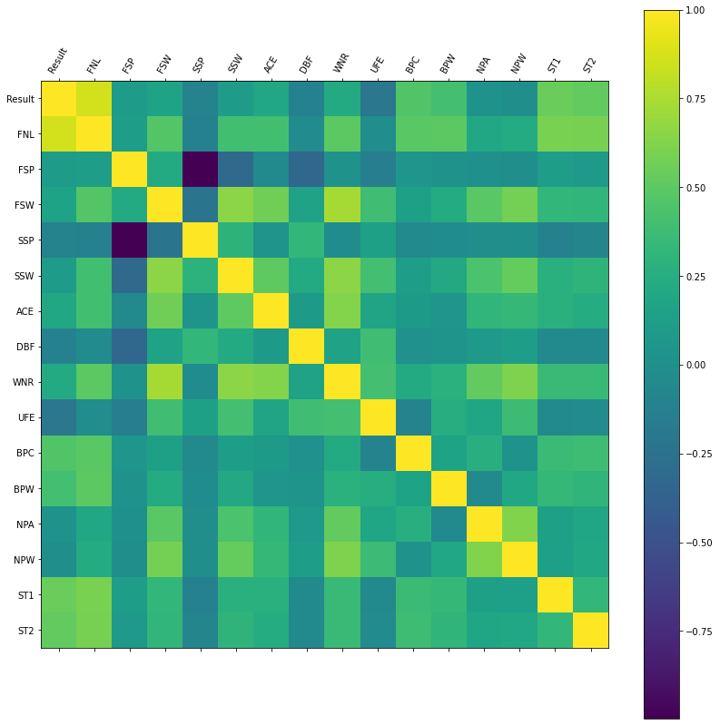

```python
# set the size of the figure
plt.rcParams["figure.figsize"] = (14,14)

# use matplotlib.pyplot.matshow() to represent an correlation matrix in a new figure window
plt.matshow(df2.corr())

# set the ticks
plt.xticks(range(len(df2.columns)), df2.columns, rotation=60)
plt.yticks(range(len(df2.columns)), df2.columns)

# set the color bar
plt.colorbar()

# draw
plt.show()
```

#### Strongest Correlations

Below we wanted to look at the attributes that had the highest correlations, not necessarily the attributes that had the highest correlations to the result.

[figure not shown]

```python
# Scatter plots for top 5 Positive and Negative correlations
fig, ((ax1, ax2), (ax3, ax4), (ax5, ax6), (ax7, ax8)) = plt.subplots(
    4, 2, figsize=(15, 15), constrained_layout=True)
fig.suptitle('Top 5 Strongest Positive and Negative correlations', size=15)

# WNR vs ACE (positive)
ax1.scatter(df2.WNR, df2.ACE, c='orange', marker='o')
ax1.set_xlabel('Net Points Attempted ', fontsize=10)
ax1.set_ylabel('Net Points Won', fontsize=10)
ax1.title.set_text('Net Points Attempted vs. Net Points Won')

# WNR vs SSW (positive)
ax2.scatter(df2.WNR, df2.SSW, c='blue', marker='o')
ax2.set_xlabel('Total Points Won', fontsize=10)
ax2.set_ylabel('Second Serve Won', fontsize=10)
ax2.title.set_text('Total Points Won vs. Second Serve Won')

# WNR vs FSW (positive)
ax3.scatter(df2.WNR, df2.FSW, c='yellow', marker='o')
ax3.set_xlabel('Total Points Won', fontsize=10)
ax3.set_ylabel('Winners Earned', fontsize=10)
ax3.title.set_text('Total Points Won vs. Winners Earned')

# BPC vs. FNL (positive)
ax4.scatter(df2.BPC, df2.FNL, c='turquoise', marker='o')
ax4.set_xlabel('First Serve Won', fontsize=10)
ax4.set_ylabel('Total Points Won', fontsize=10)
ax4.title.set_text('First Serve Won vs. Total Points Won')

# NPW vs. WNR
ax5.scatter(df2.NPW, df2.WNR, c='magenta', marker='o')
ax5.set_xlabel('First Serve Won', fontsize=10)
ax5.set_ylabel('Winners Earned', fontsize=10)
ax5.title.set_text('First Serve Won vs. Winners Earned')

# NPW vs FSW
ax6.scatter(df2.NPW, df2.FSW, c='purple', marker='o')
ax6.set_xlabel('First Serve Percentage', fontsize=10)
ax6.set_ylabel('Second Serve Percentage', fontsize=10)
ax6.title.set_text('First Serve Percentage vs. Second Serve Percentage')

# NPW vs SSW
ax7.scatter(df2.NPW, df2.SSW, c='black', marker='o')
ax7.set_xlabel('Double Faults Committed', fontsize=10)
ax7.set_ylabel('First Serve Percentage', fontsize=10)
ax7.title.set_text('Double Faults Committed vs. First Serve Percentage')

# BPW vs FNL
ax8.scatter(df2.BPW, df2.FNL, c='maroon', marker='o')
ax8.set_xlabel('Second Serve Won', fontsize=10)
ax8.set_ylabel('First Serve Percentage', fontsize=10)
ax8.title.set_text('Second Serve Won vs. First Serve Percentage')
```

#### Feature Extraction:

```python
# extract features into a new data frame
df3 = df2[['Result', 'WNR', 'BPC', 'BPW', 'ST1', 'ST2', 'UFE']]
```

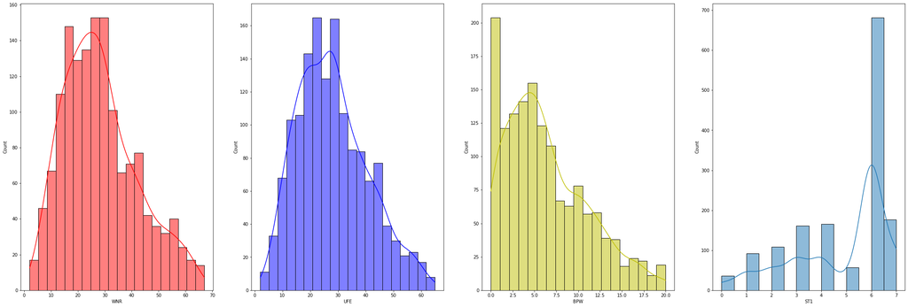

```python
# examine the distribution of the best 4 features
fig, axes = plt.subplots(1, 4, figsize=(36, 12))
sns.histplot(df3, ax=axes[0], x="WNR", kde=True, color='r')
sns.histplot(df3, ax=axes[1], x="UFE", kde=True, color='b')
sns.histplot(df3, ax=axes[2], x="BPW", kde=True, color='y')
sns.histplot(df3, ax=axes[3], x="ST1", kde=True)
```

## Part 3: Predictive Analysis

```python
# initially defining a function to print out stats for the model
def model_stats(list1_predicted, list2_test):
    '''This function just prints out correct and incorrect
    percentages for the model and the accuracy score.
    '''
    compare = list(zip(list1_predicted, list2_test))
    right = 0
    wrong = 0
    for pred, act in compare:
        if pred == act:
            right += 1
        elif pred != act:
            wrong += 1
    return print(f'{right + wrong} total predictions /'
                 f'\n{right} correct predictions /'
                 f'\n{wrong} wrong predictions /'
                 f'\nAccuracy score: {(right)/(right + wrong)}')
```

```python
# splitting test and train data:
X = np.array(df3[['WNR', 'BPW', 'UFE', 'ST1']])
y = np.array(df3['Result'])
X_train, X_test, y_train, y_test = train_test_split(X, y, test_size=.20, train_size=.80)

actual = list(y_test)
```

#### Part 3A: Logistic Regression

```python
lr = LogisticRegression()
lr.fit(X_train, y_train)
lr_pred = list(lr.predict(X_test))

#define confusion matrix
lr_cf_matrix = confusion_matrix(y_test, lr_pred)

#print accuracy score and model stats
model_stats(list(lr_pred) , actual)
```

```
296 total predictions /
251 correct predictions /
45 wrong predictions /
Accuracy score: 0.847972972972973
```

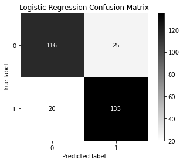

```python
# display a more visually useful correlation matrix
disp = ConfusionMatrixDisplay(lr_cf_matrix)
fig, ax = plt.subplots(figsize=(6, 4))
disp.plot(cmap='binary', ax=ax)
plt.title('Logistic Regression Confusion Matrix')
plt.show()
```

#### Part 3B: K-Nearest Neighbors

```python
knn = KNeighborsClassifier(n_neighbors=6)
knn.fit(X_train, y_train)
knn_pred = knn.predict(X_test)

#define confusion matrix
knn_cf_matrix = confusion_matrix(y_test, knn_pred)

#print accuracy score and model stats
model_stats(list(knn_pred) , actual)
```

```
296 total predictions /
235 correct predictions /
61 wrong predictions /
Accuracy score: 0.793918918918919
```

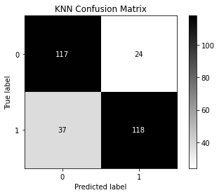

```python
# display a more visually useful correlation matrix
knn_cf_disp = ConfusionMatrixDisplay(knn_cf_matrix)
fig, ax = plt.subplots(figsize=(6, 4))
knn_cf_disp.plot(cmap='binary', ax=ax)
plt.title('KNN Confusion Matrix')
plt.show()
```

#### Part 3C: Naive Bayes

```python
gnb = GaussianNB()
gnb.fit(X_train, y_train)
nb_y_pred = gnb.predict(X_test)

#define confusion matrix
nb_cf_matrix = confusion_matrix(y_test, nb_y_pred)

#print accuracy score and model stats
model_stats(list(nb_y_pred), actual)
```

```
296 total predictions /
237 correct predictions /
59 wrong predictions /
Accuracy score: 0.8006756756756757
```

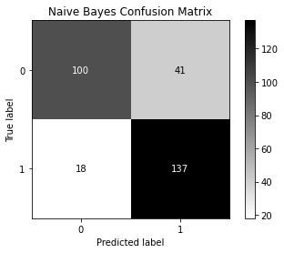

```python
# display a more visually useful correlation matrix
nb_cf_disp = ConfusionMatrixDisplay(nb_cf_matrix)
fig, ax = plt.subplots(figsize=(6, 4))
nb_cf_disp.plot(cmap='binary', ax=ax)
plt.title('Naive Bayes Confusion Matrix')
plt.show()
```

## Part 4: Conclusion

We believe our logistic regression model would be useful to professional tennis players to see how they might compete against another opponent given their historical and their opponents historical match statistics.

## Part 5: References

1. From Kris Jamsa's Introduction to Data Mining and Analytics with Machine Learning in R and Python: CancerPredictKNN.py
2. https://scikit-learn.org/stable/
3. https://pandas.pydata.org/docs/
4. https://medium.com/analytics-vidhya/visually-interpreting-the-confusion-matrix-787a70b65678